# diamonds

Devrim Nesipoğlu

4 Ocak 2018

## Assignment 3: Diamonds Price Estimation

# MEF - BDA 503

# Diamonds dataset

This dataset contains the prices and other attributes for around 50.000 diamons. The features included are the following:

- carat: Weight of the diamond
- cut: Quality of the cut (Fair/Good/Very Good/ Premium/Ideal)
- color: Diamond color, ranging from J (worst) to D (best)
- clarity: A measurement of how clear the diamond is (I1 (worst), SI1, SI2, VS1, VS2, VVS1, VVS2, IF (best))
- depth: Total depth percentage = z / mean(x, y) = 2 * z / (x + y) (43–79)
- table: Width of top of diamond relative to widest point (43–95)
- price: Price in US dollars ($326–$18,823)
- x: Length in mm (0–10.74)
- y: Width in mm (0–58.9)
- z: Depth in mm (0–31.8)

```r
library(rpart)
library(rpart.plot)
library(tidyverse)
library(ggplot2) # Data visualization
library(readr) # CSV file I/O, e.g. the read_csv function
library(ggvis)
library(dplyr)
library(caret)
```

# Exploratory Data Analysis

General information about Diamonds dataset:

```r
data(diamonds)
str(diamonds)
```

```
## Classes 'tbl_df', 'tbl' and 'data.frame':    53940 obs. of  10 variables:
##  $ carat  : num  0.23 0.21 0.23 0.29 0.31 0.24 0.24 0.26 0.22 0.23 ...
##  $ cut    : Ord.factor w/ 5 levels "Fair"<"Good"<..: 5 4 2 4 2 3 3 3 1 3 ...
##  $ color  : Ord.factor w/ 7 levels "D"<"E"<"F"<"G"<..: 2 2 2 6 7 7 6 5 2 5 ...
##  $ clarity: Ord.factor w/ 8 levels "I1"<"SI2"<"SI1"<..: 2 3 5 4 2 6 7 3 4 5 ...
##  $ depth  : num  61.5 59.8 56.9 62.4 63.3 62.8 62.3 61.9 65.1 59.4 ...
##  $ table  : num  55 61 65 58 58 57 57 55 61 61 ...
##  $ price  : int  326 326 327 334 335 336 336 337 337 338 ...
##  $ x      : num  3.95 3.89 4.05 4.2 4.34 3.94 3.95 4.07 3.87 4 ...
##  $ y      : num  3.98 3.84 4.07 4.23 4.35 3.96 3.98 4.11 3.78 4.05 ...
##  $ z      : num  2.43 2.31 2.31 2.63 2.75 2.48 2.47 2.53 2.49 2.39 ...
```

```r
dim(diamonds)
```

```
## [1] 53940    10
```

```r
##result=>53940 observation  , 10 variable

summary(diamonds)
```

```
##      carat               cut        color        clarity
##  Min.   :0.2000   Fair     : 1610   D: 6775   SI1    :13065
##  1st Qu.:0.4000   Good     : 4906   E: 9797   VS2    :12258
##  Median :0.7000   Very Good:12082   F: 9542   SI2    : 9194
##  Mean   :0.7979   Premium  :13791   G:11292   VS1    : 8171
##  3rd Qu.:1.0400   Ideal    :21551   H: 8304   VVS2   : 5066
##  Max.   :5.0100                     I: 5422   VVS1   : 3655
##                                     J: 2808   (Other): 2531
##      depth           table           price             x
##  Min.   :43.00   Min.   :43.00   Min.   :  326   Min.   : 0.000
##  1st Qu.:61.00   1st Qu.:56.00   1st Qu.:  950   1st Qu.: 4.710
##  Median :61.80   Median :57.00   Median : 2401   Median : 5.700
##  Mean   :61.75   Mean   :57.46   Mean   : 3933   Mean   : 5.731
##  3rd Qu.:62.50   3rd Qu.:59.00   3rd Qu.: 5324   3rd Qu.: 6.540
##  Max.   :79.00   Max.   :95.00   Max.   :18823   Max.   :10.740
##
##        y                z
##  Min.   : 0.000   Min.   : 0.000
##  1st Qu.: 4.720   1st Qu.: 2.910
##  Median : 5.710   Median : 3.530
##  Mean   : 5.735   Mean   : 3.539
##  3rd Qu.: 6.540   3rd Qu.: 4.040
##  Max.   :58.900   Max.   :31.800
##
```

```r
##result=>cut ,colar,clarity =>factors
```

```r
df <- diamonds[,c(1,2,3,4,5,6,7)]
str(df)
```

```
## Classes 'tbl_df', 'tbl' and 'data.frame':    53940 obs. of  7 variables:
##  $ carat  : num  0.23 0.21 0.23 0.29 0.31 0.24 0.24 0.26 0.22 0.23 ...
##  $ cut    : Ord.factor w/ 5 levels "Fair"<"Good"<..: 5 4 2 4 2 3 3 3 1 3 ...
##  $ color  : Ord.factor w/ 7 levels "D"<"E"<"F"<"G"<..: 2 2 2 6 7 7 6 5 2 5 ...
##  $ clarity: Ord.factor w/ 8 levels "I1"<"SI2"<"SI1"<..: 2 3 5 4 2 6 7 3 4 5 ...
##  $ depth  : num  61.5 59.8 56.9 62.4 63.3 62.8 62.3 61.9 65.1 59.4 ...
##  $ table  : num  55 61 65 58 58 57 57 55 61 61 ...
##  $ price  : int  326 326 327 334 335 336 336 337 337 338 ...
```

```r
head(df)
```

```
## # A tibble: 6 x 7
##   carat       cut color clarity depth table price
##   <dbl>     <ord> <ord>   <ord> <dbl> <dbl> <int>
## 1  0.23     Ideal     E     SI2  61.5    55   326
## 2  0.21   Premium     E     SI1  59.8    61   326
## 3  0.23      Good     E     VS1  56.9    65   327
## 4  0.29   Premium     I     VS2  62.4    58   334
## 5  0.31      Good     J     SI2  63.3    58   335
## 6  0.24 Very Good     J    VVS2  62.8    57   336
```

# ggplot2

ggplot2 is a plotting system for R, based on Leland Wilkinson’s “The grammar of graphics”.

# qplot

The qplot function is a convenient wrapper for creating a number of different types of plots using a consistent scheme. It is recommended for simple scatterplots. This function creates a ggplot object which will receive the actual plot.

# geom

An important parameter is geom. It specifies the geometric objects that define the graph type. Geom values include:

- point
- smooth
- boxplot
- line
- histogram
- density
- bar
- jitter

using the pipe operator:

diamonds %>% qplot(carat, price, data = .)

# Create a scatterplot for comparing price based on diamond cut and color

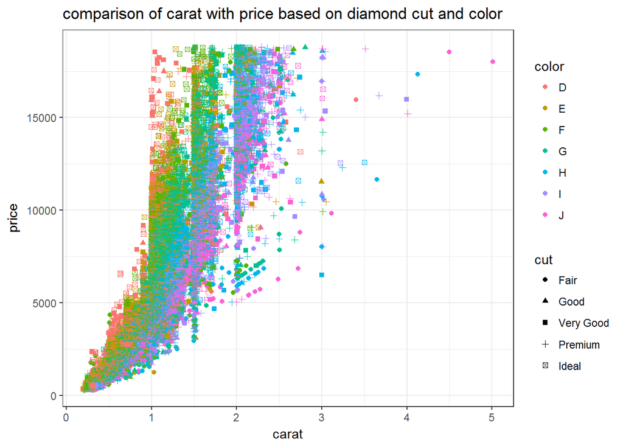

```r
theme_set(theme_bw())
ggplot(diamonds,aes(x=carat,y=price))+geom_jitter(aes(color=color,shape=cut))+
labs(title="comparison of carat with price based on diamond cut and color")
```

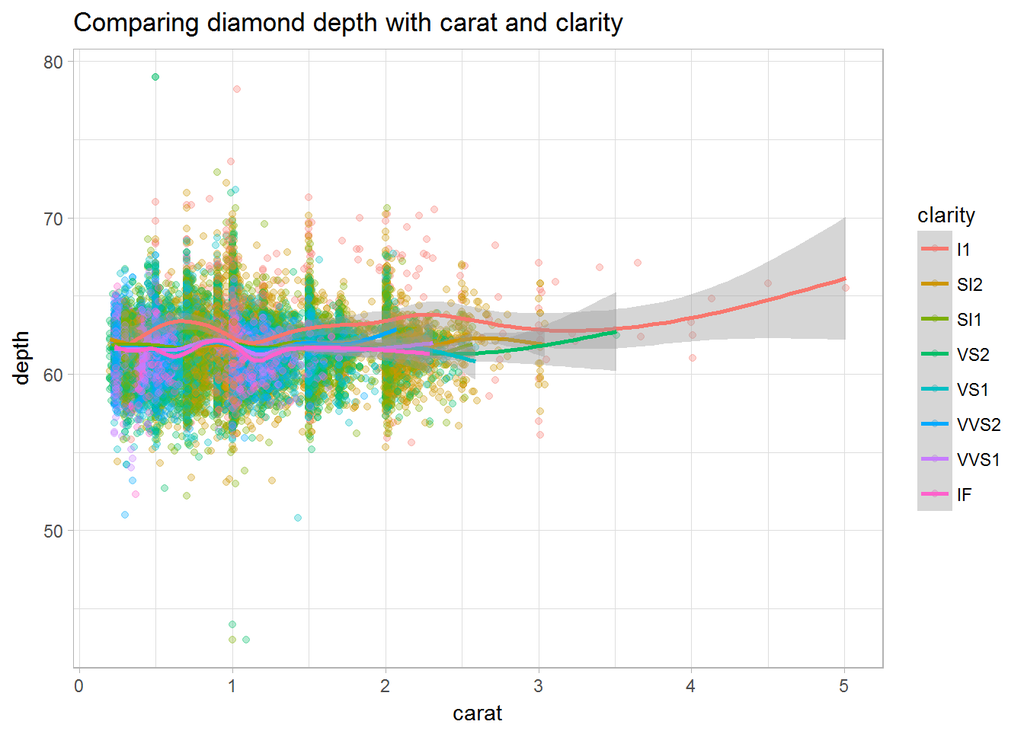

```r
ggplot(diamonds, aes(x=carat, y=depth, color=clarity)) + geom_point(alpha=0.3) + geom_smooth() +theme_light()+
labs(title="Comparing diamond depth with carat and clarity")
```

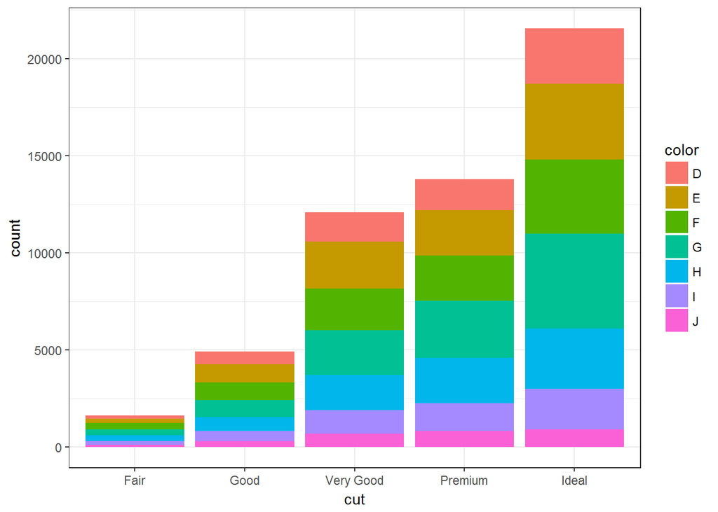

```r
ggplot(diamonds,aes(x=cut,fill=color))+geom_bar()
```

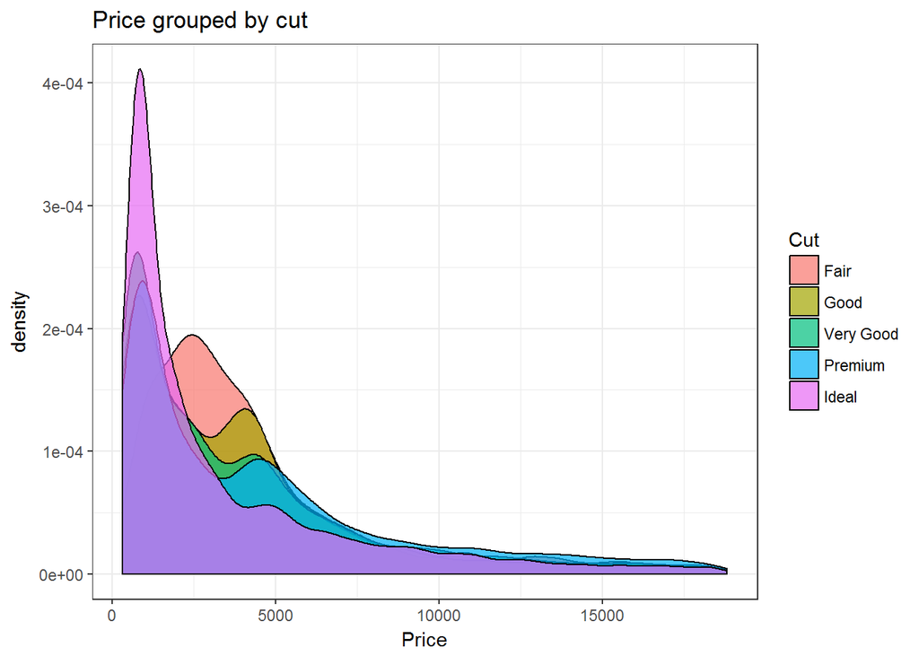

```r
ggplot(diamonds,aes(x=price))+geom_density(aes(fill=factor(cut)),alpha=0.7)+labs(title="Price grouped by cut",x="Price",fill="Cut")
```

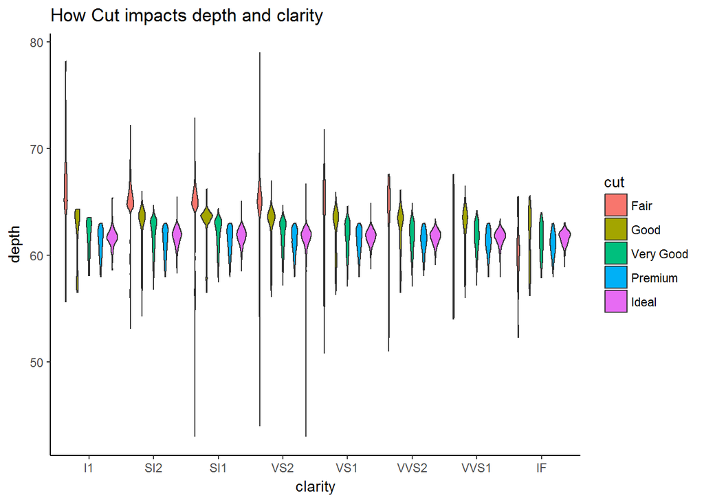

```r
ggplot(diamonds,aes(x=clarity,y=depth))+geom_violin(aes(fill=cut))+theme_classic()+labs(title="How Cut impacts depth and clarity")
```